# GroupB_Final

S.Carpenè, G.Fantuzzi, V.Nigam, M.Tallone, A.Valentinis

2024-02-14

# Problem statement and dataset

The `BankChurners` dataset contains information about a bank’s costumers and their credit card usage. The dataset is available on the Kaggle website and it is used for a classification problem. The main goal is to predict the `Attrition_Flag` response variable, which basically explains whether a customer will churn or not. The dataset consist of 10127 observations and 21 variables.

# Data preparation and EDA (Exploratory Data Analysis)

With the exclusion of the first variable (`CLIENTNUM`), that is just an identification number, and the last two (`Naive_Bayes_Classifier...`) variables, the dataset contains 19 possible covariates to be used for prediction. Among these, there are 6 categorical variables and 13 numerical variables.

The `Attrition_Flag` variable is the response variable and it is a binary variable. As it’s possible to see form the following barplot, the dataset is unbalanced, with only 16.07% of the observations being positive, i.e. a churned costumer, for the `Attrition_Flag` variable.  
For this reason, in the some of the models presented in this report, we attempted to balance the dataset using the *ROSE* package. Below the proportion for the originl dataset and the balanced one are reported.

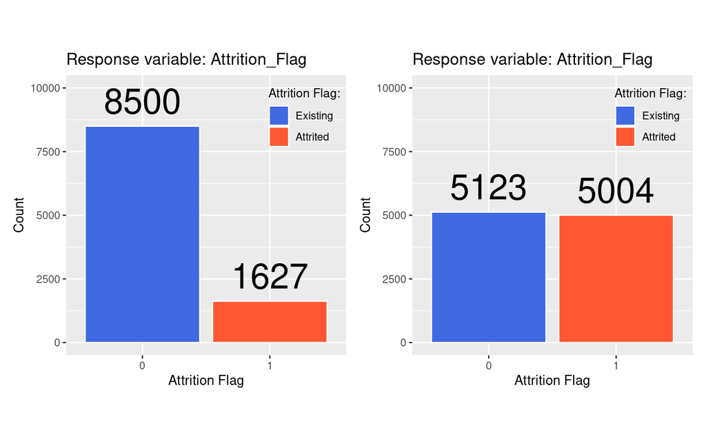

```
## Proportion of attrited (original dataset): 16.06596 %
```

```
## Proportion of attrited (ROSE): 49.41246 %
```

For what regards the available covariates, instead, we first checked for possible correlation between the variables by computing the correlation matrix and we plotted it using a heatmap. The correlation matrix is the following:

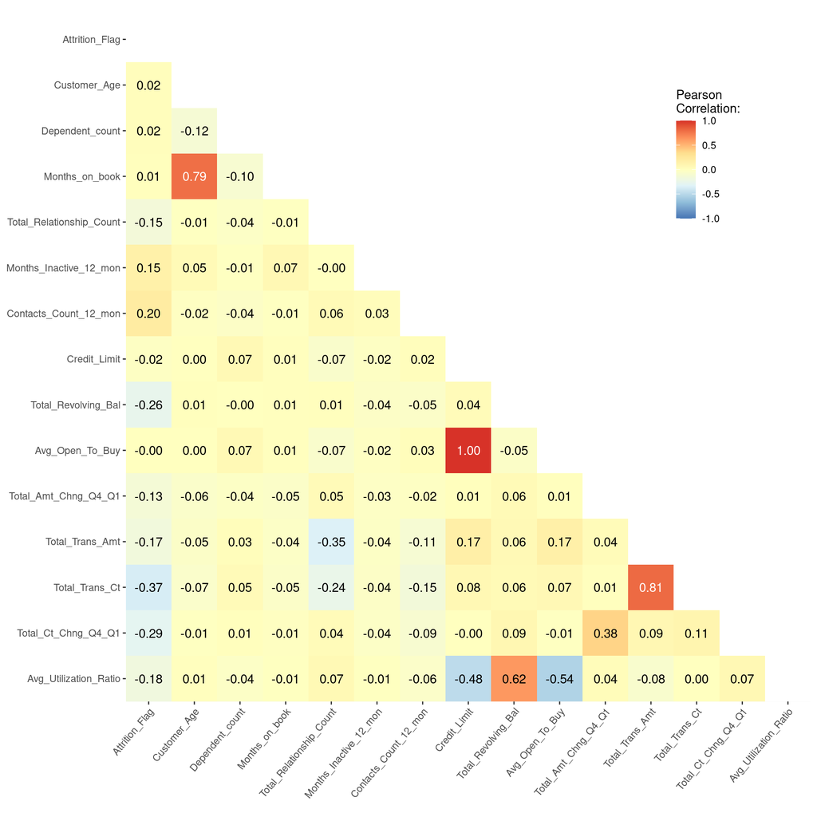

- the `Avg_Open_To_Buy` and `Credit_Limit` variables, which are totally correlated: this appeared to us particularly strange as its also highligted by the plot of the two variables below;
- the `Months_on_book` and `Customer_Age` variables, that are reasonably correlated with a correlation of 0.79: indeed one expects that the number of months a customer has been with the bank is related to the customer’s age;
- the `Total_Trans_Amt` and `Total_Trans_Ct` variables, that show a correlation of 0.81;
- the `Total_Revolving_Bal` and `Avg_Utilization_Ratio` variables, that are also highly correlated with a correlation of 0.62.

As we can see from the plot below the plot of the two totally correlated variables `Avg_Open_To_Buy` and `Credit_Limit` shows a seemingly perfect linear relationship, which we found quite anomalous.

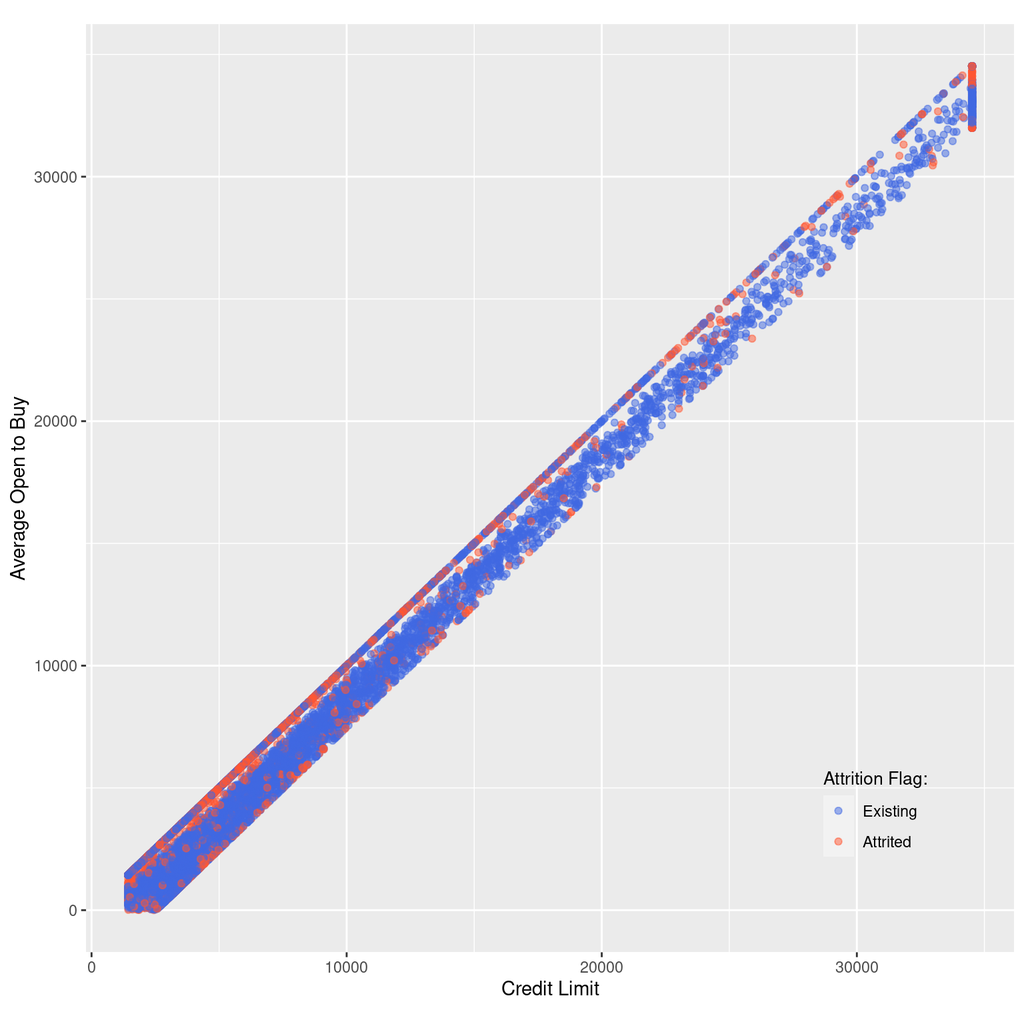

Since both the `Total_Trans_Amt` and `Total_Trans_Ct` variables are highly correlated between each other but, contrairly to the other variables, also show a significant correlation with the response variable, it made sense to plot the two variables in the following scatter plot to check for possible patterns.

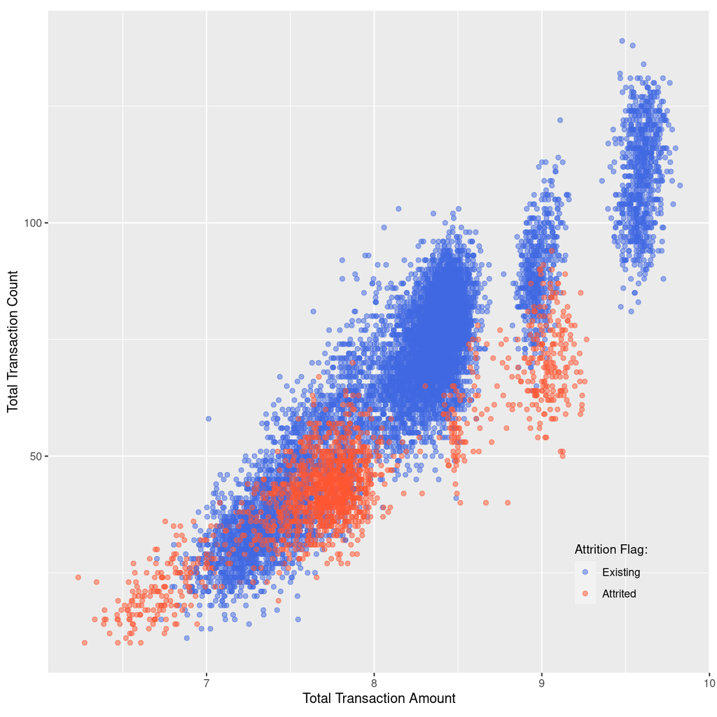

The scatter plot represents the total number of transactions (on the y axis) agains the logarithm of the total transaction amount (on the x axis). The plot is colored by the `Attrition_Flag` variable, and we can indeed visually confirm the correlation among the two variables. However we can also spot that the churned customers are more concentrated in the lower left part of the plot.  
This fact is also reflected in the distribution analysis of the two variables reported below.

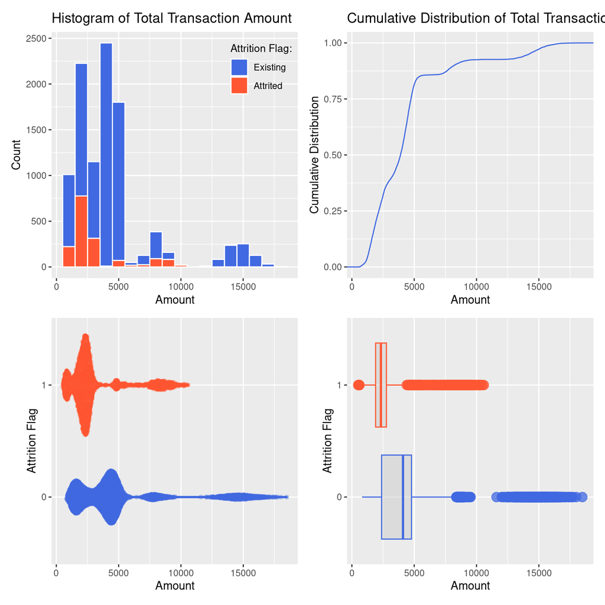

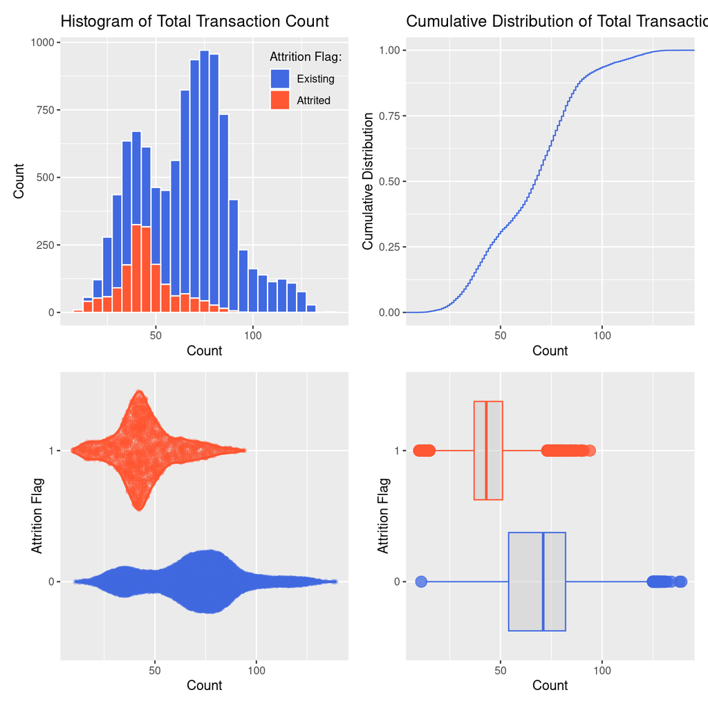

```r
# plot_discrete(bank, Total_Trans_Ct, "Total Transaction Count", "Count")
plot_continuous(bank, Total_Trans_Ct, "Total Transaction Count", "Count", 5)
```

# Models implementation

Different models has been built to predict the `Attrition_Flag` variable and are presented in this section. In order to assess the model performance, different effectiveness metrics have been used. These have been computed both by fitting the model using all the observations in the dataset and also by performing a k-fold cross validation with $k=10$. The metrics used are the following:

- Accuracy
- AUC
- FPR (False Positive Rate)
- FNR (False Negative Rate)
- Confusion matrix (*only for a single static split*)

The Dummy classifier has been taken as a baseline for comparison.

## Logistic regression

The first model we build in the attempt of predicting the response variable has been a logistic regression model using the $logit$ link function.  
In the initial model we included all the covariates except those that had low correlation with the response variable. We further filtered the covariates selection by discarding the variables that had a $p-value$ higher than 0.05 in the `glm()` summary output, i.e. the variables that were not statistically significant in the prediction.  
The final model has been built using the following variables:

- `Gender`: the gender of the customer
- `Marital_Status`: the marital status of the customer
- `Income_Category`: the income category of the customer
- `Total_Relationship_Count`: the total number of products held by the customer
- `Months_Inactive_12_mon`: the number of months inactive in the last 12 months
- `Contacts_Count_12_mon`: the number of contacts in the last 12 months
- `Total_Revolving_Bal`: the total revolving balance on the credit card
- `Total_Trans_Ct`: the total transaction count in the last 12 months
- `Total_Ct_Chng_Q4_Q1`: the change in transaction count from Q4 to Q1

Aditionally, for this particular model, all of the numerical variables have been standardized to have a mean of 0 and a standard deviation of 1. Some covariates have also been slightly modified to improve the model performance. Among these we mention that:

- the `Marital_Status` variable has been converted into a binary variable, taking the levels “Married” and “Not Married” since this change helped improving the statitical significane of the variable in the final model.
- the variable `Income_Category` has also been converted into a binary variable, dividing the clients in two categories: those with an income less than 120K and those with an income more than 120K.

All of these changes have significantly improved the model performance as portrayed by the metrics explained below. An ANOVA test has also been performed to check the significance of the model. The results of the ANOVA test are the following:

```r
anova(simple_logistic_model, test = "Chisq")
```

|  | Df | Deviance | Resid. Df | Resid. Dev | Pr(>Chi) |
| --- | --- | --- | --- | --- | --- |
| NULL | NA | NA | 10126 | 8927.195 | NA |
| Gender | 1 | 14.120652 | 10125 | 8913.074 | 1.714511e-04 |
| Marital_Status | 1 | 5.525513 | 10124 | 8907.549 | 1.874111e-02 |
| Income_Category | 1 | 4.988372 | 10123 | 8902.560 | 2.551820e-02 |
| Total_Relationship_Count | 1 | 226.246751 | 10122 | 8676.314 | 3.925476e-51 |
| Months_Inactive_12_mon | 1 | 229.616191 | 10121 | 8446.697 | 7.228451e-52 |
| Contacts_Count_12_mon | 1 | 493.006588 | 10120 | 7953.691 | 3.159490e-109 |
| Total_Revolving_Bal | 1 | 627.749021 | 10119 | 7325.942 | 1.543086e-138 |
| Total_Trans_Ct | 1 | 1787.955005 | 10118 | 5537.987 | 0.000000e+00 |
| Total_Ct_Chng_Q4_Q1 | 1 | 329.250862 | 10117 | 5208.736 | 1.399430e-73 |

As its possible to see all the covariates contribute in decreasing the deviance of the model, and they are all statistically significant. Looking at these results it’s surely possible to see that the contribution in the deviance decrease of the two categorical variables `Marital_Status` and `Income_Category` is lower than the other variables, so an attempt to simplify the model by removing these 2 variables can be done. However, both for comparisons purposes and for the sake of the model performance, we decided to keep these variables in the model.  
On the other hand, possible multicollinearity problems, especially among the variables that showed high correlation in the exploratory analysis, were checked by looking at the Variance Inflation Factor (VIF) of the covariates.

```
##                   Gender           Marital_Status          Income_Category Total_Relationship_Count   Months_Inactive_12_mon    Contacts_Count_12_mon
##                 1.143142                 1.057974                 1.116890                 1.112759                 1.020334                 1.018628
##      Total_Revolving_Bal           Total_Trans_Ct      Total_Ct_Chng_Q4_Q1
##                 1.040250                 1.259977                 1.048022
```

### Results on the original dataset

On the given dataset, the built logistic model summary is the following:

```r
summary(simple_logistic_model)
```

```
##
## Call:
## glm(formula = Attrition_Flag ~ . - Total_Trans_Amt, family = binomial(link = "logit"),
##     data = data)
##
## Deviance Residuals:
##     Min       1Q   Median       3Q      Max
## -2.6679  -0.4140  -0.2118  -0.0917   3.7272
##
## Coefficients:
##                               Estimate Std. Error z value Pr(>|z|)
## (Intercept)                   -2.30354    0.06594 -34.934  < 2e-16 ***
## GenderM                       -0.56470    0.07695  -7.339 2.16e-13 ***
## Marital_StatusMarried         -0.50893    0.07403  -6.875 6.22e-12 ***
## Income_CategoryMore than 120K  0.38345    0.14187   2.703  0.00687 **
## Total_Relationship_Count      -0.83190    0.04091 -20.333  < 2e-16 ***
## Months_Inactive_12_mon         0.45430    0.03590  12.653  < 2e-16 ***
## Contacts_Count_12_mon          0.50767    0.03771  13.462  < 2e-16 ***
## Total_Revolving_Bal           -0.74256    0.03606 -20.593  < 2e-16 ***
## Total_Trans_Ct                -1.52621    0.05029 -30.346  < 2e-16 ***
## Total_Ct_Chng_Q4_Q1           -0.64456    0.04078 -15.805  < 2e-16 ***
## ---
## Signif. codes:  0 '***' 0.001 '**' 0.01 '*' 0.05 '.' 0.1 ' ' 1
##
## (Dispersion parameter for binomial family taken to be 1)
##
##     Null deviance: 8927.2  on 10126  degrees of freedom
## Residual deviance: 5208.7  on 10117  degrees of freedom
## AIC: 5228.7
##
## Number of Fisher Scoring iterations: 6
```

For what concerns the effectiveness metrics, we measured the following results on the original dataset:

```r
logistic_results <- assess_logistic(simple_logistic_model, bank_logistic)
```

```
## ----------------------------------------
##           Predicted
## Actual     Existing Attrited
##   Existing     8233      267
##   Attrited      752      875
## ----------------------------------------
## Accuracy: 89.94 %
## Dummy classifier accuracy: 83.93 %
## ----------------------------------------
## AUC: 90.14 %
## Dummy classifier AUC: 50 %
## ----------------------------------------
## FPR: 3.14 %
## FNR: 46.22 %
## ----------------------------------------
## AIC: 5228.736
## BIC: 5300.966
## ----------------------------------------
```

```r
cv_logistic(bank_logistic)
```

[output not shown]

### Results on the synthetic dataset (ROSE)

As said in the beginning we also tried to balance the dataset using the *ROSE* package. Let’s apply *ROSE* package:

```r
bank_logistic_balanced<- ROSE(Attrition_Flag~.,data=bank_logistic,seed = 123)$data
```

Now we can learn a logistic regression model on the new balanced dataset:

```r
ROSE_logistic_model <- learn_logistic(bank_logistic_balanced)
```

For what concerns the effectiveness metrics on the static trai test split:

```r
ROSE_logistic_results<- assess_logistic(ROSE_logistic_model, bank_logistic_balanced)
```

```
## ----------------------------------------
##           Predicted
## Actual     Existing Attrited
##   Existing     4187      936
##   Attrited      987     4017
## ----------------------------------------
## Accuracy: 81.01 %
## Dummy classifier accuracy: 50.59 %
## ----------------------------------------
## AUC: 88.69 %
## Dummy classifier AUC: 50 %
## ----------------------------------------
## FPR: 18.27 %
## FNR: 19.72 %
## ----------------------------------------
## AIC: 8617.685
## BIC: 8689.915
## ----------------------------------------
```

Instead, by computing a 10-fold CV:

```r
cv_logistic(bank_logistic_balanced)
```

```
## ----------------------------------------
## Average accuracy: 80.95 +/- 1.32 %
## ----------------------------------------
## Average AUC: 88.64 +/- 1.03 %
## ----------------------------------------
## Average FPR: 18.16 +/- 2.38 %
## Average FNR: 20.03 +/- 1.66 %
## ----------------------------------------
## Average AIC: 7757.018 +/- 35.55373
## Average BIC: 7828.194 +/- 35.55369
## ----------------------------------------
```

## GAM/Splines

The assessment has been done using the same procedure as the logistic regression model: we performed a k-fold cross validation with k=10, and we used the same metrics.

### Results on the original dataset

The build gamfit model is:

```r
gamfit<-learn_gam(bank_gam)
summary(gamfit)
```

```
##
## Family: binomial
## Link function: logit
##
## Formula:
## Attrition_Flag ~ s(Customer_Age) + Gender + Marital_Status +
##     Total_Relationship_Count + Months_Inactive_12_mon + Contacts_Count_12_mon +
##     s(Total_Revolving_Bal) + s(Total_Amt_Chng_Q4_Q1) + s(Total_Trans_Amt) +
##     s(Total_Trans_Ct) + s(Total_Ct_Chng_Q4_Q1)
##
## Parametric coefficients:
##                          Estimate Std. Error z value Pr(>|z|)
## (Intercept)              -7.71594    4.47696  -1.723 0.084802 .
## GenderM                  -0.57222    0.12301  -4.652 3.29e-06 ***
## Marital_StatusMarried    -0.65156    0.12520  -5.204 1.95e-07 ***
## Total_Relationship_Count -0.47334    0.04402 -10.752  < 2e-16 ***
## Months_Inactive_12_mon1  -3.80487    0.99070  -3.841 0.000123 ***
## Months_Inactive_12_mon2  -2.41885    0.97927  -2.470 0.013510 *
## Months_Inactive_12_mon3  -2.02770    0.97614  -2.077 0.037777 *
## Months_Inactive_12_mon4+ -1.53849    0.98660  -1.559 0.118907
## Contacts_Count_12_mon     0.44961    0.05739   7.834 4.73e-15 ***
## ---
## Signif. codes:  0 '***' 0.001 '**' 0.01 '*' 0.05 '.' 0.1 ' ' 1
##
## Approximate significance of smooth terms:
##                           edf Ref.df Chi.sq p-value
## s(Customer_Age)         7.878  8.167  114.2  <2e-16 ***
## s(Total_Revolving_Bal)  8.633  8.959  397.9  <2e-16 ***
## s(Total_Amt_Chng_Q4_Q1) 5.741  6.299  152.6  <2e-16 ***
## s(Total_Trans_Amt)      8.961  8.999  707.1  <2e-16 ***
## s(Total_Trans_Ct)       7.680  7.908  460.5  <2e-16 ***
## s(Total_Ct_Chng_Q4_Q1)  3.312  4.232  108.7  <2e-16 ***
## ---
## Signif. codes:  0 '***' 0.001 '**' 0.01 '*' 0.05 '.' 0.1 ' ' 1
##
## R-sq.(adj) =  0.799   Deviance explained = 78.9%
## UBRE = -0.80364  Scale est. = 1         n = 10127
```

Regarding the effectiveness metrics we obtained:

```r
gam_results <- assess_gam(gamfit, bank_gam)
```

```
## ----------------------------------------
##           Predicted
## Actual     Existing Attrited
##   Existing     8351      149
##   Attrited      215     1412
## ----------------------------------------
## Accuracy: 96.41 %
## Dummy classifier accuracy: 83.93 %
## ----------------------------------------
## AUC: 98.93 %
## Dummy classifier AUC: 50 %
## ----------------------------------------
## FPR: 1.75 %
## FNR: 13.21 %
## ----------------------------------------
## AIC: 1988.499
## BIC: 2358.341
## ----------------------------------------
```

And similar results for the k-fold cross validation:

```r
cv_gam(bank_gam)
```

```
## ----------------------------------------
## Average accuracy: 96.09 +/- 0.32 %
## ----------------------------------------
## Average AUC: 98.78 +/- 0.3 %
## ----------------------------------------
## Average FPR: 1.88 +/- 0.48 %
## Average FNR: 15.14 +/- 2.13 %
## ----------------------------------------
## Average AIC: 1792.46 +/- 20.78768
## Average BIC: 2143.593 +/- 23.51102
## ----------------------------------------
```

### Results on the synthetic dataset (ROSE)

First of all, let’s obtain the synthetic dataset:

```r
bank_gam_balanced<- ROSE(Attrition_Flag~.,data=bank_gam,seed = 123)$data
```

Learning phase of the model:

```r
ROSE_gamfit<-learn_gam(bank_gam_balanced)
```

```r
ROSE_gam_results<- assess_gam(ROSE_gamfit, bank_gam_balanced)
```

```
## ----------------------------------------
##           Predicted
## Actual     Existing Attrited
##   Existing     4279      844
##   Attrited      714     4290
## ----------------------------------------
## Accuracy: 84.62 %
## Dummy classifier accuracy: 50.59 %
## ----------------------------------------
## AUC: 92.67 %
## Dummy classifier AUC: 50 %
## ----------------------------------------
## FPR: 16.47 %
## FNR: 14.27 %
## ----------------------------------------
## AIC: 7078.448
## BIC: 7418.736
## ----------------------------------------
```

```r
cv_gam(bank_gam_balanced)
```

```
## ----------------------------------------
## Average accuracy: 84.44 +/- 0.85 %
## ----------------------------------------
## Average AUC: 92.41 +/- 0.59 %
## ----------------------------------------
## Average FPR: 17.17 +/- 1.88 %
## Average FNR: 14.11 +/- 1.94 %
## ----------------------------------------
## Average AIC: 6375.474 +/- 29.13573
## Average BIC: 6702.61 +/- 29.0921
## ----------------------------------------
```

## Ensemble Methods

The last class of methods we used to model the `Attrition_Flag` variable is ensamble methods, in particular we focussed on AdaBoost and Random Forest.  
The first model we built is an AdaBoost model on the whole dataset, which on its own achieved some great results. Then we proceeded by removing the variables considered not statistically significant in more complex models like `GAM`. This slight modification didn’t much modify the accuracy of the model, which is always on the order of about $\sim90\%$.  
The final model has been built using the following variables:

- `Gender`: the gender of the customer
- `Total_Relationship_Count`: the total number of products held by the customer
- `Months_Inactive_12_mon`: the number of months inactive in the last 12 months
- `Contacts_Count_12_mon`: the number of contacts in the last 12 months
- `Total_Revolving_Bal`: the total revolving balance on the credit card
- `Total_Trans_Amt`: the total transaction amount in the last 12 months
- `Total_Trans_Ct`: the total transaction count in the last 12 months
- `Total_Ct_Chng_Q4_Q1`: the change in transaction count from Q4 to Q1
- `Marital_Status`: the marital status of the customer
- `Income_Category`: the income category of the customer

The same pre-processing steps of the `GLM` model were performed, slightly modifying classes or taking logarithmic values and converting the `Months_Inactive_12_mon` variable to a factor.  
The effectiveness metrics used to assess the model are:

- Accuracy
- AUC
- FPR (False Positive Rate)
- FNR (False Negative Rate)
- Confusion matrix
- Variable importance

The dummy classifier has been taken as a baseline for comparison.

Learning phase:

```r
boost_model <- learn_boost(train_bank_ensamble)
rf_model <- learn_rf(train_bank_ensamble)
```

### Results on the original dataset

A summary-like output of the model doesn’t exist, but we can still assess the model performance using the metrics described above.

First we show the results relative to a single run of the model on the dataset:

```r
boost_results <- assess_boost(boost_model, test_bank_ensamble)
```

```
## ----------------------------------------
##           Predicted
## Actual     Existing Attrited
##   Existing     1673       27
##   Attrited       55      270
## ----------------------------------------
## Accuracy: 95.95 %
## Dummy classifier accuracy: 83.95 %
## ----------------------------------------
## AUC: 98.4 %
## Dummy classifier AUC: 50 %
## ----------------------------------------
## FPR: 1.59 %
## FNR: 16.92 %
## ----------------------------------------
## Variable importance:
##                    Variable Mean_Gini_Decrease
## 1            Total_Trans_Ct         32.1290080
## 2           Total_Trans_Amt         28.0619350
## 3       Total_Ct_Chng_Q4_Q1         11.6521977
## 4       Total_Revolving_Bal         11.4968680
## 5  Total_Relationship_Count          6.9770316
## 6     Contacts_Count_12_mon          3.9556203
## 7    Months_Inactive_12_mon          3.6111736
## 8                    Gender          0.8720491
## 9            Marital_Status          0.8677845
## 10          Income_Category          0.3763321
## ----------------------------------------
```

Then the results on a 10-fold cross validation:

```r
cv_boost_results <- cv_boost(bank_ensamble)
```

```
## ----------------------------------------
## Average accuracy: 95.8 +/- 0.62 %
## ----------------------------------------
## Average AUC: 98.58 +/- 0.33 %
## ----------------------------------------
## Average FPR: 2.14 +/- 0.52 %
## Average FNR: 14.94 +/- 3.76 %
## ----------------------------------------
## Average variable importance ranking:
##                    Variable Mean_Gini_Decrease   Std_Dev
## 1            Total_Trans_Ct         34.4238144 1.3462097
## 2           Total_Trans_Amt         27.5899608 1.1064890
## 3       Total_Revolving_Bal         12.3707367 0.5727565
## 4       Total_Ct_Chng_Q4_Q1         10.4054774 0.5674450
## 5  Total_Relationship_Count          6.9797462 0.4778131
## 6     Contacts_Count_12_mon          3.7719677 0.3688566
## 7    Months_Inactive_12_mon          2.7936159 0.4302681
## 8            Marital_Status          0.8467934 0.2544696
## 9                    Gender          0.5970740 0.1421272
## 10          Income_Category          0.2208136 0.1068953
## ----------------------------------------
```

As we can see from these results, AdaBoost is performing pretty well, having a consistent accuracy of over $90\%$ and a good AUC score. The FPR and FNR are also very low, keeping them consistently under $20\%$. Not having an AIC or BIC-like score, we can’t really compare the model to the previous ones, but the results on classification are much better than the ones above, in particular with respect to the simple logistic regression.

Passing to Random Forest, we perform the same analysis:

```r
rf_results <- assess_rf(rf_model, test_bank_ensamble)
```

```
## ----------------------------------------
##           Predicted
## Actual     Existing Attrited
##   Existing     1676       24
##   Attrited       65      260
## ----------------------------------------
## Accuracy: 95.6 %
## Dummy classifier accuracy: 83.95 %
## ----------------------------------------
## AUC: 98.14 %
## Dummy classifier AUC: 50 %
## ----------------------------------------
## FPR: 1.41 %
## FNR: 20 %
## ----------------------------------------
## Variable importance:
##                    Variable Mean_Gini_Decrease
## 8           Total_Trans_Amt         529.807126
## 9            Total_Trans_Ct         485.608407
## 7       Total_Revolving_Bal         393.019449
## 10      Total_Ct_Chng_Q4_Q1         318.191270
## 4  Total_Relationship_Count         205.084791
## 6     Contacts_Count_12_mon          90.515870
## 5    Months_Inactive_12_mon          85.966817
## 1                    Gender          35.993873
## 2            Marital_Status          23.708807
## 3           Income_Category           8.235691
## ----------------------------------------
```

```r
cv_rf_results <- cv_rf(bank_ensamble)
```

```
## ----------------------------------------
## Average accuracy: 95.88 +/- 0.6 %
## ----------------------------------------
## Average AUC: 98.53 +/- 0.39 %
## ----------------------------------------
## Average FPR: 1.65 +/- 0.39 %
## Average FNR: 18.63 +/- 5.07 %
## ----------------------------------------
## Average variable importance ranking:
##                    Variable Mean_Gini_Decrease    Std_Dev
## 1           Total_Trans_Amt         594.260721  1.2329108
## 2            Total_Trans_Ct         547.113190  0.7216613
## 3       Total_Revolving_Bal         417.708629  0.3330579
## 4       Total_Ct_Chng_Q4_Q1         381.125419  6.4603938
## 5  Total_Relationship_Count         229.326038  2.3368698
## 6     Contacts_Count_12_mon         100.106859  1.8307071
## 7    Months_Inactive_12_mon          95.318035  6.7189635
## 8                    Gender          41.048829  8.6463686
## 9            Marital_Status          28.676287 10.6508919
## 10          Income_Category           8.953285  5.7820735
## ----------------------------------------
```

### Results on the synthetic dataset (ROSE)

From `bank_ensamble` let’s obtain a new (synthetic) dataset:

```r
bank_ensamble_balanced<- ROSE(Attrition_Flag~.,data=bank_ensamble,seed = 123)$data
```

It is now splitted into a training and test set (to be consistent, we use the same seed used before)

```r
set.seed(1234)
index <- createDataPartition(bank_ensamble_balanced$Attrition_Flag , p =0.8, list = FALSE)
train_bank_ensamble_balanced <- bank_ensamble_balanced[index,]
test_bank_ensamble_balanced <- bank_ensamble_balanced[-index,]
```

Learning phase:

```r
ROSE_boost_model <- learn_boost(train_bank_ensamble_balanced)
ROSE_rf_model <- learn_rf(train_bank_ensamble_balanced)
```

Assessment with static train/test division:

```r
assess_boost(ROSE_boost_model, test_bank_ensamble_balanced)
```

```
## ----------------------------------------
##           Predicted
## Actual     Existing Attrited
##   Existing      909      115
##   Attrited      125      875
## ----------------------------------------
## Accuracy: 88.14 %
## Dummy classifier accuracy: 50.59 %
## ----------------------------------------
## AUC: 95.05 %
## Dummy classifier AUC: 50 %
## ----------------------------------------
## FPR: 11.23 %
## FNR: 12.5 %
## ----------------------------------------
## Variable importance:
##                    Variable Mean_Gini_Decrease
## 1            Total_Trans_Ct         37.6403899
## 2       Total_Revolving_Bal         16.4268728
## 3           Total_Trans_Amt         14.3267798
## 4       Total_Ct_Chng_Q4_Q1         10.2729640
## 5  Total_Relationship_Count          8.1545128
## 6     Contacts_Count_12_mon          5.2552011
## 7    Months_Inactive_12_mon          5.1071983
## 8                    Gender          2.2144963
## 9            Marital_Status          0.4120053
## 10          Income_Category          0.1895795
## ----------------------------------------
```

[output not shown]

```r
assess_rf(ROSE_rf_model, test_bank_ensamble_balanced)
```

```
## ----------------------------------------
##           Predicted
## Actual     Existing Attrited
##   Existing      914      110
##   Attrited      114      886
## ----------------------------------------
## Accuracy: 88.93 %
## Dummy classifier accuracy: 50.59 %
## ----------------------------------------
## AUC: 95.16 %
## Dummy classifier AUC: 50 %
## ----------------------------------------
## FPR: 10.74 %
## FNR: 11.4 %
## ----------------------------------------
## Variable importance:
##                    Variable Mean_Gini_Decrease
## 9            Total_Trans_Ct         1128.96533
## 7       Total_Revolving_Bal          716.12825
## 10      Total_Ct_Chng_Q4_Q1          582.52131
## 8           Total_Trans_Amt          569.04631
## 4  Total_Relationship_Count          410.95159
## 6     Contacts_Count_12_mon          304.87890
## 5    Months_Inactive_12_mon          198.64647
## 1                    Gender           75.76350
## 2            Marital_Status           39.82138
## 3           Income_Category           17.30200
## ----------------------------------------
```

[output not shown]

Assessment with 10-fold cross validation:

```r
cv_boost(bank_ensamble_balanced)
```

```
## ----------------------------------------
## Average accuracy: 88.29 +/- 0.75 %
## ----------------------------------------
## Average AUC: 95.17 +/- 0.62 %
## ----------------------------------------
## Average FPR: 12.1 +/- 1.79 %
## Average FNR: 11.31 +/- 1.31 %
## ----------------------------------------
## Average variable importance ranking:
##                    Variable Mean_Gini_Decrease    Std_Dev
## 1            Total_Trans_Ct        43.40710960 1.73955820
## 2       Total_Revolving_Bal        15.58571936 0.84827820
## 3           Total_Trans_Amt        12.51666409 0.85500979
## 4  Total_Relationship_Count         9.23701706 0.55708039
## 5       Total_Ct_Chng_Q4_Q1         8.30573006 0.54036127
## 6    Months_Inactive_12_mon         4.72837157 0.41733906
## 7     Contacts_Count_12_mon         4.21194321 0.35294187
## 8                    Gender         1.69962154 0.29090438
## 9            Marital_Status         0.22237409 0.06810999
## 10          Income_Category         0.08544943 0.04295257
## ----------------------------------------
```

[output not shown]

```r
cv_rf(bank_ensamble_balanced)
```

```
## ----------------------------------------
## Average accuracy: 88.7 +/- 1.06 %
## ----------------------------------------
## Average AUC: 95.22 +/- 0.68 %
## ----------------------------------------
## Average FPR: 11.64 +/- 1.55 %
## Average FNR: 10.98 +/- 1.49 %
## ----------------------------------------
## Average variable importance ranking:
##                    Variable Mean_Gini_Decrease    Std_Dev
## 1            Total_Trans_Ct         1284.98064  2.9413457
## 2       Total_Revolving_Bal          798.58666  0.9267807
## 3       Total_Ct_Chng_Q4_Q1          654.72786  0.5683626
## 4           Total_Trans_Amt          648.81875  4.3651613
## 5  Total_Relationship_Count          448.64834  6.3442106
## 6     Contacts_Count_12_mon          343.65904  6.8771990
## 7    Months_Inactive_12_mon          221.61611 12.3352178
## 8                    Gender           83.57163  4.8320908
## 9            Marital_Status           44.55261 12.5320615
## 10          Income_Category           18.70678 13.3440374
## ----------------------------------------
```

[output not shown]

# Interpretations/Conclusions

In conlusion, we recall here them main results of the models we built:

[output not shown]

Visually we can compare the performance of the models using the following plots.

- Accuracy:

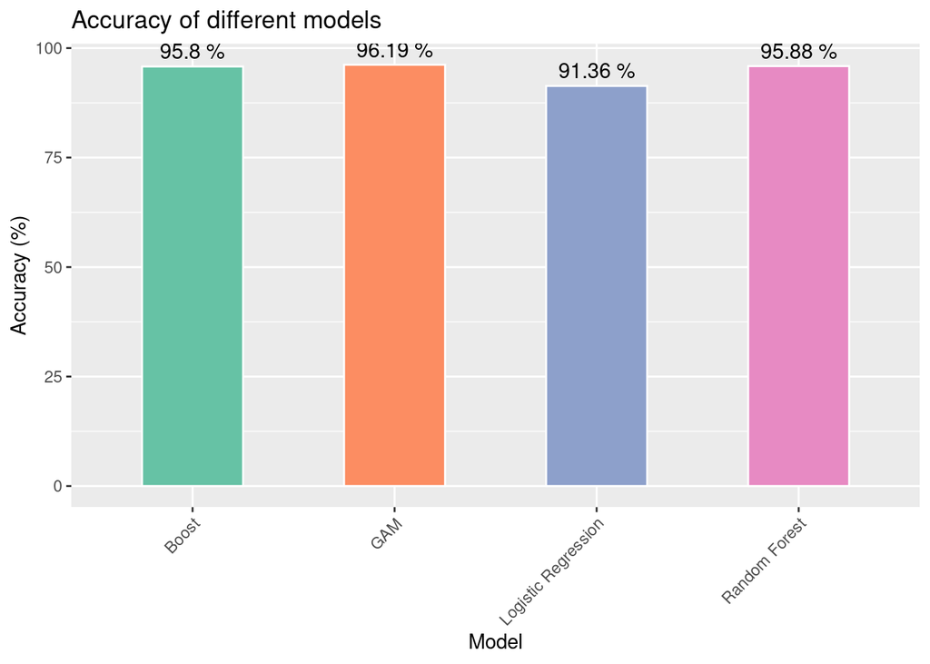

- AUC:

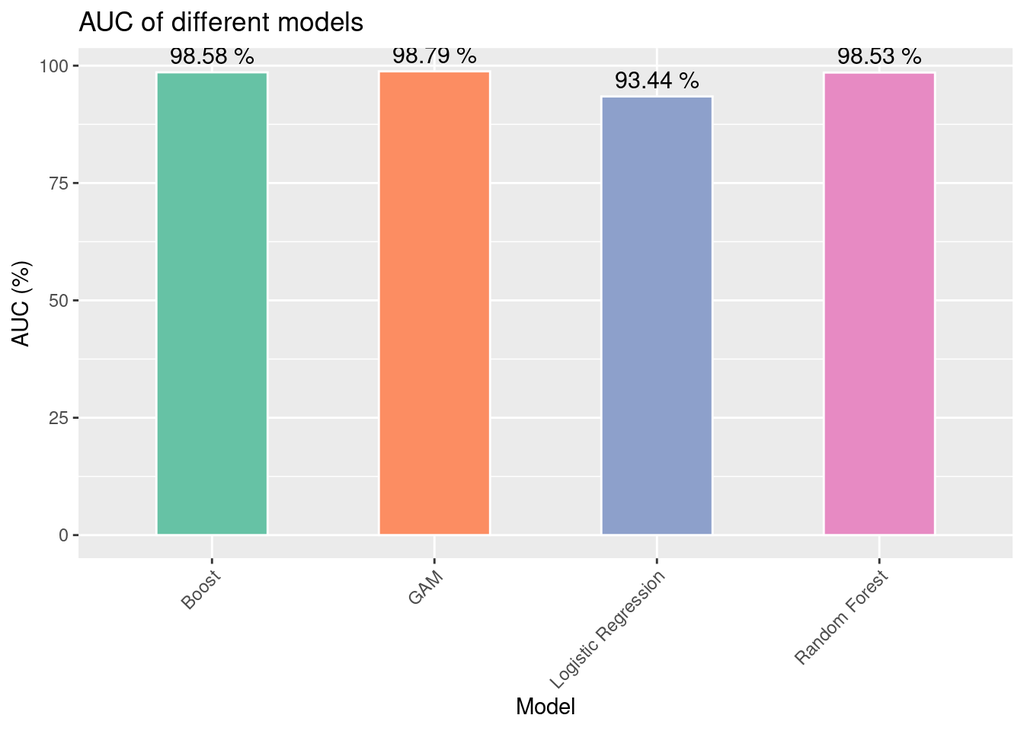

- FPR (False Posiitve Rate):

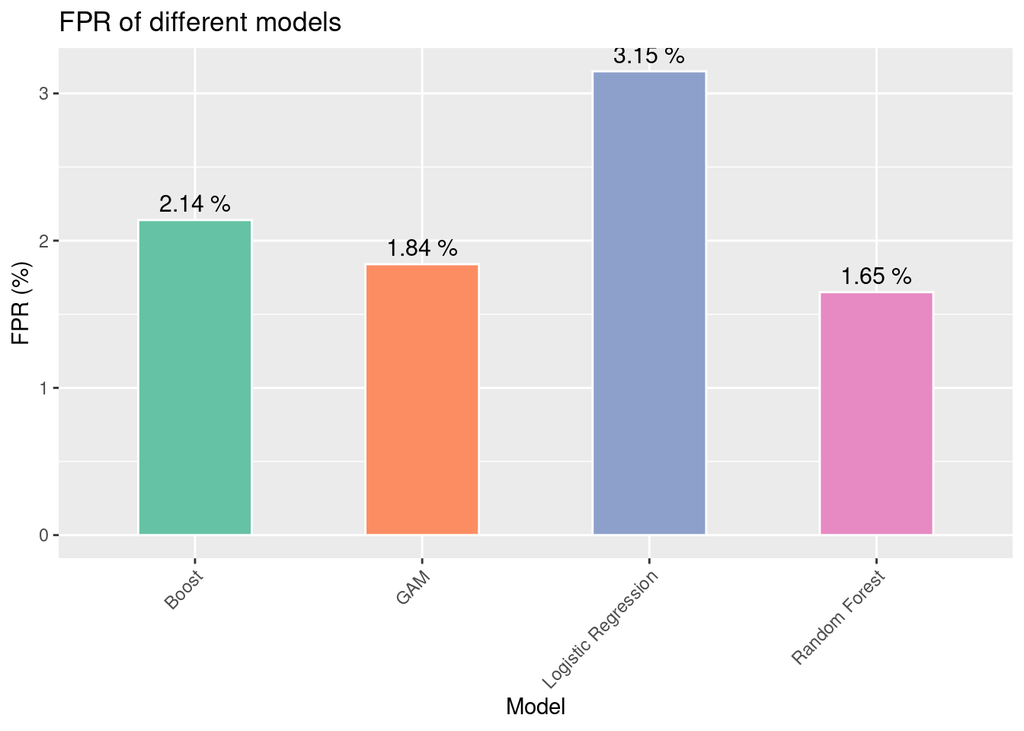

- FNR (False Negative Rate):

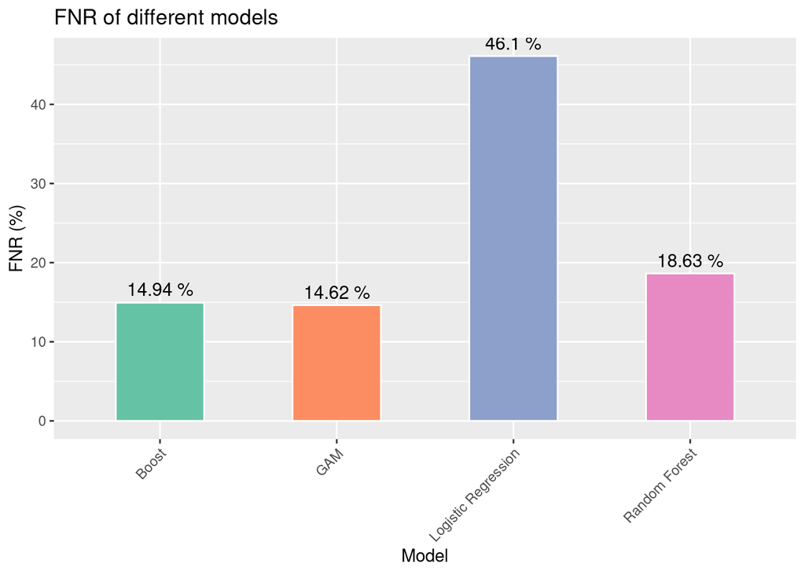

We can also visually compre the ranking of variables importance built using the Random Forest Classifier in a 10-cross fold validation:

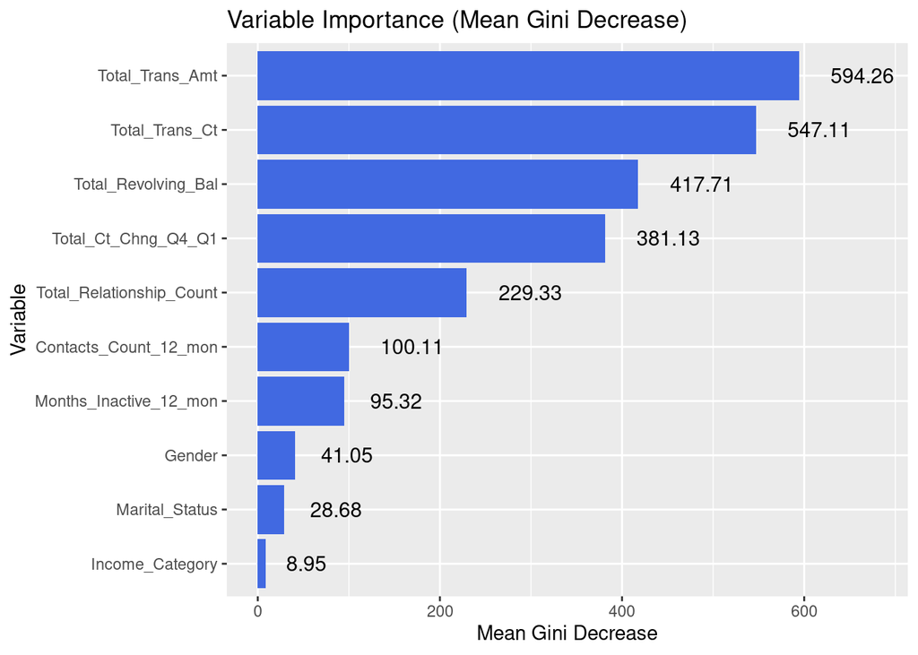